# Organización y limpieza de datos

Sesión 1

Luis F. Gomez L.

luis.gomezl@unimilitar.edu.co

Facultad de Estudios a Distancia

2026-11-03

# Preliminares

- Verificar:
  - ¿La carpeta `data` fue creada?
  - ¿El archivo `serie-nacional-de-poblacion_area-sexo-edad_2018-2070_2025-07-18.xlsx` fue incluído en `data`?
- Instalar paquetes:
  - `install.packages("janitor")`
- Generar carpetas:
  - `016_datos-ordenados-en-r`
    - Crear archivo `001_datos-ordenados.R`
  - `017_pivotear-datos-en-r`
    - Crear archivo `001_pivotear.R`

# Datos ordenados

- El concepto de **datos ordenados** (en inglés **tidy data**), propuesto por Hadley Wickham (Wickham 2014), proporciona un marco para vincular:
  - La **estructura** de un conjunto de datos (su disposición en filas y columnas) con su **semántica** (su significado real).
- Este estándar permite:
  - Simplificar las etapas iniciales de limpieza.
  - Facilitar la exploración y modelado de datos.
  - Asegurar que los paquetes del `tidyverse` interactúen sin fricciones.

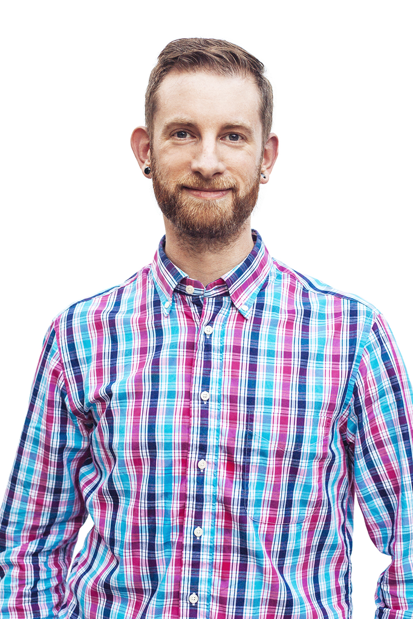

Figura 1: Hadley Wickham

## Estructura de datos

- Gran parte de los conjuntos de datos se organizan en **tablas rectangulares** compuestas por **filas** y **columnas**.
- En la práctica, las columnas casi siempre se identifican mediante encabezados y las filas en ocasiones cuentan con etiquetas (Wickham 2014).
- Sin embargo, una misma información puede presentarse en disposiciones físicas muy diferentes.
- Consideremos un experimento médico hipotético analizado en (Wickham 2014), donde se evalúa el resultado de 2 tratamientos (**a** y **b**) en 3 individuos (**John Smith**, **Jane Doe** y **Mary Johnson**).

## Estructura de datos

### Tabla de presentación vs. Tabla transpuesta

**Tabla de presentación**

Tabla 1: Filas y columnas etiquetadas

| individuo | **a** | **b** |
| --- | --- | --- |
| John Smith | NA | 2 |
| Jane Doe | 16 | 11 |
| Mary Johnson | 3 | 1 |

**Tabla transpuesta**

Tabla 2: Filas y columnas transpuestas

| tratamiento | John Smith | Jane Doe | Mary Johnson |
| --- | --- | --- | --- |
| **a** | NA | 16 | 3 |
| **b** | 2 | 11 | 1 |

Ambas tablas transmiten **exactamente la misma información**, pero su disposición física y espacial es totalmente distinta. Por tanto, el vocabulario habitual de “filas” y “columnas” es insuficiente: se requiere examinar la **semántica** de los datos (Wickham 2014).

## Semántica de datos

### Estructura vinculada a la semántica

Tabla 3: Variables en columnas y observaciones en filas

| individuo | tratamiento | resultado |
| --- | --- | --- |
| John Smith | a | NA |
| Jane Doe | a | 16 |
| Mary Johnson | a | 3 |
| John Smith | b | 2 |
| Jane Doe | b | 11 |
| Mary Johnson | b | 1 |

- Se hacen explícitos los **18 valores** correspondientes a **3 variables** y **6 observaciones**:
  - **`individuo`**: 3 valores posibles (`John Smith`, `Jane Doe`, `Mary Johnson`).
  - **`tratamiento`**: 2 valores posibles (`a` y `b`).
  - **`resultado`**: mediciones cuantitativas y valor ausente (`NA`, `16`, `3`, `2`, `11`, `1`).

## Semántica de datos

### Gestión de valores ausentes

El diseño del estudio define la estructura de las observaciones y cómo deben gestionarse los valores ausentes:

- **Valores ausentes estructurales**:
  - Representan mediciones que **no pueden ocurrir** por la propia naturaleza del fenómeno (por ejemplo, el número de partos en individuos masculinos).
  - Estos registros pueden descartarse sin pérdida de rigor.
- **Valores ausentes explícitos**:
  - Representan observaciones que **debieron haberse registrado**, pero por alguna circunstancia se omitieron o no se obtuvieron (como el tratamiento `a` en `John Smith`).
  - Es fundamental conservarlos explícitamente como valores ausentes (`NA` en R).

## Características de datos ordenados

De acuerdo con Wickham (Wickham 2014, 2023), un conjunto de datos es **ordenado** si satisface 4 reglas fundamentales:

1. **Cada variable forma una columna**.
2. **Cada observación forma una fila**.
3. **Cada valor es una celda**.
4. **Cada tipo de unidad observacional forma una tabla**.

> Cualquier disposición física que no cumpla con estas reglas se clasifica como **datos no ordenados** (en inglés **non-tidy data**).

# Problemas más comunes con datos no ordenados

## Problemas habituales

En la práctica, los datos suelen encontrarse en formatos no ordenados. La gran mayoría de las dificultades estructurales se reducen a **5 problemas habituales** (Wickham 2014):

1. Nombres de columnas que representan **valores y no nombres de variables**.
2. **Múltiples variables** combinadas en una sola columna.
3. Variables distribuidas simultáneamente en **filas y en columnas**.
4. Múltiples **unidades observacionales** mezcladas en una sola tabla.
5. Una misma unidad observacional fragmentada en **múltiples tablas o archivos**.

## Nombres de columnas que son valores, no variables

- Ocurre frecuentemente en tablas para reportes donde los encabezados corresponden a niveles o categorías de una variable.
- Para reestructurar estas tablas se utiliza la función `pivot_longer()` del paquete `tidyr`.
- Transforma múltiples columnas en un par de columnas `nombre`-`valor` (*name*-*value*), aumentando filas y reduciendo columnas.

## Nombres de columnas que son valores, no variables

### Ejemplo 1: `relig_income`

- Los encabezados (`<$10k`, `$10-20k`, … , `Don't know/refused`) representan valores de la variable `ingreso`.

```r
# Cargar paquetes ----
library(tidyverse)

# Pivotear a formato largo ----
relig_income |>
  pivot_longer(
    cols = `<$10k`:`Don't know/refused`,
    names_to = "ingreso",
    values_to = "frecuencia"
  )
```

```
# A tibble: 180 × 3
   religion ingreso            frecuencia
   <chr>    <chr>                   <dbl>
 1 Agnostic <$10k                      27
 2 Agnostic $10-20k                    34
 3 Agnostic $20-30k                    60
 4 Agnostic $30-40k                    81
 5 Agnostic $40-50k                    76
 6 Agnostic $50-75k                   137
 7 Agnostic $75-100k                  122
 8 Agnostic $100-150k                 109
 9 Agnostic >150k                      84
10 Agnostic Don't know/refused         96
# ℹ 170 more rows
```

## Nombres de columnas que son valores, no variables

### Ejemplo 2: `billboard`

- Las columnas `wk1` a `wk76` corresponden a semanas del ranking: son valores de una única variable (`semana`).

```r
# Pivotear a formato largo ----
billboard |>
  pivot_longer(
    cols = wk1:wk76,
    names_to = "semana",
    values_to = "posicion",
    values_drop_na = TRUE
  )
```

```
# A tibble: 5,307 × 5
   artist  track                   date.entered semana posicion
   <chr>   <chr>                   <date>       <chr>     <dbl>
 1 2 Pac   Baby Don't Cry (Keep... 2000-02-26   wk1          87
 2 2 Pac   Baby Don't Cry (Keep... 2000-02-26   wk2          82
 3 2 Pac   Baby Don't Cry (Keep... 2000-02-26   wk3          72
 4 2 Pac   Baby Don't Cry (Keep... 2000-02-26   wk4          77
 5 2 Pac   Baby Don't Cry (Keep... 2000-02-26   wk5          87
 6 2 Pac   Baby Don't Cry (Keep... 2000-02-26   wk6          94
 7 2 Pac   Baby Don't Cry (Keep... 2000-02-26   wk7          99
 8 2Ge+her The Hardest Part Of ... 2000-09-02   wk1          91
 9 2Ge+her The Hardest Part Of ... 2000-09-02   wk2          87
10 2Ge+her The Hardest Part Of ... 2000-09-02   wk3          92
# ℹ 5,297 more rows
```

## Múltiples variables en una sola columna

- Surge cuando los encabezados unen 2 o más variables dentro de una sola etiqueta compuesta.
- Ejemplo: conjunto de datos de tuberculosis (`tb`), donde columnas como `m_014` agrupan:
  - **Sexo**: `m` (masculino) y `f` (femenino).
  - **Rango de edad**: `014` (0 a 14 años) y `1524` (15 a 24 años).
- Para ordenar:
  1. `pivot_longer()` para agrupar las columnas compuestas en una columna intermedia `demo`.
  2. `separate_wider_delim()` para dividir `demo` en `sexo` y `edad`.

## Múltiples variables en una sola columna

### Construcción con `tribble()`

- La función `tribble()` del paquete `tibble` permite definir tablas fila por fila para ejemplos o demostraciones:
  - Los nombres de columna inician con virgulilla (`~`).
  - Los valores se ingresan a lo largo de las filas separados por comas.

```r
# Crear muestra de datos ----
tb_muestra <- tribble(
  ~iso2 , ~year , ~m_014 , ~m_1524 , ~f_014 , ~f_1524 ,
  "AD"  ,  2000 ,      0 ,       0 ,      1 ,       1 ,
  "AE"  ,  2000 ,      2 ,       4 ,      3 ,       4 ,
  "AF"  ,  2000 ,     52 ,     228 ,     93 ,     140
)

tb_muestra
```

```
# A tibble: 3 × 6
  iso2   year m_014 m_1524 f_014 f_1524
  <chr> <dbl> <dbl>  <dbl> <dbl>  <dbl>
1 AD     2000     0      0     1      1
2 AE     2000     2      4     3      4
3 AF     2000    52    228    93    140
```

## Múltiples variables en una sola columna

### Reestructurar y separar variables

```r
# Pivotear y separar variables ----
tb_muestra |>
  pivot_longer(
    cols = `m_014`:`f_1524`,
    names_to = "demo",
    values_to = "casos"
  ) |>
  separate_wider_delim(
    cols = demo,
    delim = "_",
    names = c("sexo", "edad")
  )
```

```
# A tibble: 12 × 5
   iso2   year sexo  edad  casos
   <chr> <dbl> <chr> <chr> <dbl>
 1 AD     2000 m     014       0
 2 AD     2000 m     1524      0
 3 AD     2000 f     014       1
 4 AD     2000 f     1524      1
 5 AE     2000 m     014       2
 6 AE     2000 m     1524      4
 7 AE     2000 f     014       3
 8 AE     2000 f     1524      4
 9 AF     2000 m     014      52
10 AF     2000 m     1524    228
11 AF     2000 f     014      93
12 AF     2000 f     1524    140
```

## Variables almacenadas en filas y columnas

- Es la forma más compleja: ciertas variables están distribuidas a lo largo de las columnas, mientras otras variables tienen sus nombres almacenados como valores dentro de filas.
- Ejemplo: registros meteorológicos diarios de la estación MX17004 (2010):
  - Los días del mes se encuentran dispersos en columnas (`1`, `2`, `3`).
  - La columna `element` almacena nombres de variables (`tmax` y `tmin`) como valores de fila.
- Para ordenarlos se combinan `pivot_longer()` y `pivot_wider()`.

## Variables almacenadas en filas y columnas

### Muestra de datos meteorológicos

```r
# Crear muestra de clima ----
clima_muestra <- tribble(
  ~id       , ~ano , ~mes , ~element , ~`1` , ~`2` , ~`3` ,
  "MX17004" , 2010 ,    1 , "tmax"   , NA   , NA   , NA   ,
  "MX17004" , 2010 ,    1 , "tmin"   , NA   , NA   , NA   ,
  "MX17004" , 2010 ,    2 , "tmax"   , NA   , 27.3 , 24.1 ,
  "MX17004" , 2010 ,    2 , "tmin"   , NA   , 14.4 , 14.4 ,
  "MX17004" , 2010 ,    3 , "tmax"   , NA   , NA   , NA   ,
  "MX17004" , 2010 ,    3 , "tmin"   , NA   , NA   , NA
)

clima_muestra
```

```
# A tibble: 6 × 7
  id        ano   mes element `1`     `2`   `3`
  <chr>   <dbl> <dbl> <chr>   <lgl> <dbl> <dbl>
1 MX17004  2010     1 tmax    NA     NA    NA
2 MX17004  2010     1 tmin    NA     NA    NA
3 MX17004  2010     2 tmax    NA     27.3  24.1
4 MX17004  2010     2 tmin    NA     14.4  14.4
5 MX17004  2010     3 tmax    NA     NA    NA
6 MX17004  2010     3 tmin    NA     NA    NA
```

## Variables almacenadas en filas y columnas

### Combinación `pivot_longer()` y `pivot_wider()`

```r
# Colapsar días y pivotear variables ----
clima_muestra |>
  pivot_longer(
    cols = `1`:`3`,
    names_to = "dia",
    values_to = "valor",
    values_drop_na = TRUE
  ) |>
  mutate(dia = as.integer(dia)) |>
  pivot_wider(
    names_from = element,
    values_from = valor
  )
```

```
# A tibble: 2 × 6
  id        ano   mes   dia  tmax  tmin
  <chr>   <dbl> <dbl> <int> <dbl> <dbl>
1 MX17004  2010     2     2  27.3  14.4
2 MX17004  2010     2     3  24.1  14.4
```

## Diferentes unidades observacionales en una sola tabla

- Ocurre cuando un conjunto de datos recopila información de diferentes unidades observacionales dentro de una misma tabla.
- **Consecuencias**:
  - Duplicación redundante de registros y aumento innecesario del tamaño.
  - Riesgo elevado de inconsistencias al actualizar información.
- **Solución relacional** (modelo Saber-Pro):
  - Estructurar en tablas independientes conectadas por llaves primarias (**PK**) y foráneas (**FK**).
  - Tabla de eventos: `Resultado Saber-Pro` (evaluación individual por estudiante y año).
  - Tablas de entidades: `Departamento`, `Municipio`, `Programa académico`.

## Diferentes unidades observacionales en una sola tabla

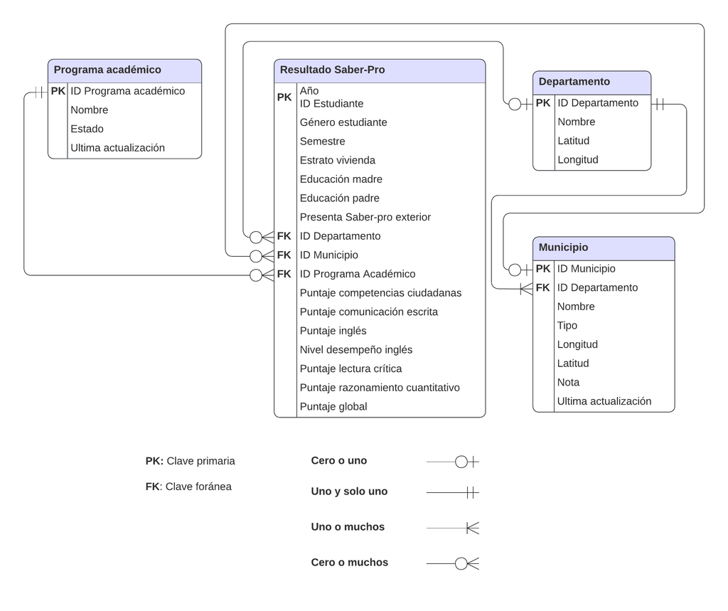

Figura 2: Diagrama Entidad-Relación Saber-Pro

Esta separación evita redundancias. Cuando se requiere analizar la información integrada, se recupera mediante **mutating joins** como `left_join()`.

## Una misma unidad observacional almacenada en múltiples tablas

- Ocurre cuando los datos de una misma unidad observacional se encuentran fragmentados en múltiples tablas o archivos independientes.
- **Ejemplo**: resultados anuales del examen Saber-Pro en archivos separados:
  - `2021-saber_pro-genericas.csv`
  - `2022-saber_pro-genericas.csv`
  - `2023-saber_pro-genericas.csv`
  - `2024-saber_pro-genericas.csv`
- Aunque comparten variables y la misma unidad de análisis, su fragmentación dificulta realizar análisis longitudinales o comparativos.

## Una misma unidad observacional almacenada en múltiples tablas

### Flujo de trabajo estándar

1. **Identificar rutas**: ubicar las rutas de cada uno de los archivos a consolidar.
2. **Lectura iterativa**: leer cada archivo asegurando registrar el año o archivo de origen.
3. **Unir filas**: consolidar todas las filas en una única tabla identificando las columnas comunes (p. ej. `bind_rows()`).

> En las sesiones de **Programación funcional** abordaremos cómo automatizar este proceso utilizando las herramientas del paquete `purrr`.

# Pivoteo

## Pirámides poblaciones

- En esta sección estructuraremos un conjunto de datos en **formato largo** utilizando el paquete `tidyr` mediante `pivot_longer()` (Wickham 2023, cap. 5).
- Emplearemos proyecciones y retroproyecciones oficiales de población nacional (2018–2070) de Colombia elaboradas por el DANE a partir del Censo Nacional de Población y Vivienda (CNPV) 2018.
- Combinaremos la **gramática de manipulación de datos** (`dplyr`) y la **gramática de gráficos en capas** (`ggplot2`) para obtener como producto final las pirámides poblacionales de Colombia.

## Pirámides poblaciones

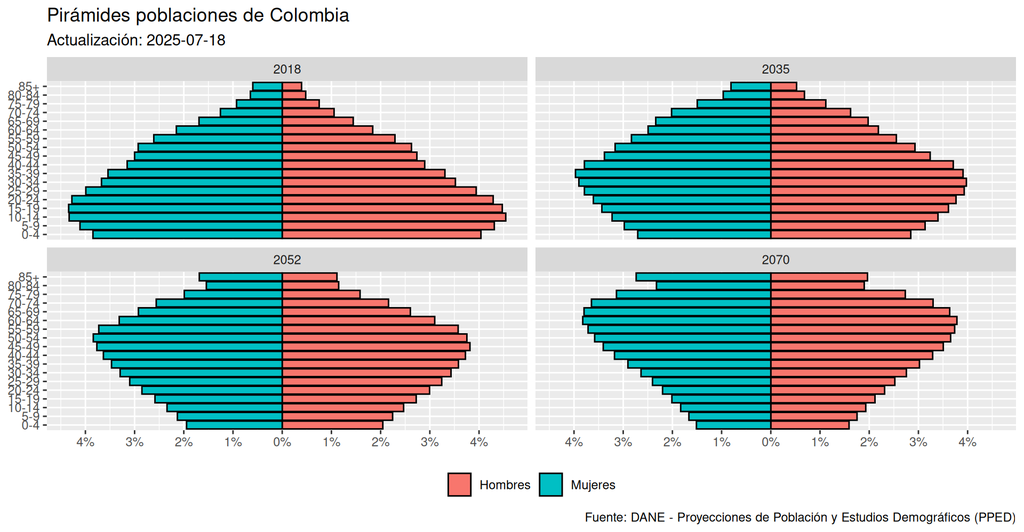

Figura 3: Resultado final de un gráfico de pirámides poblacionales utilizando `readxl`, `janitor`, `tidyr`, `ggplot2` y `scales`

## Formato largo

- El **formato largo** (*longer format*) reorganiza una tabla **aumentando el número de filas y reduciendo el de columnas** (“alargar” los datos).
- Se requiere cuando los nombres de ciertas columnas no son variables, sino **valores o niveles específicos** de una variable.
- En `tidyr`, la función `pivot_longer()` cuenta con 3 parámetros fundamentales (Wickham 2023, cap. 5):
  1. **`cols`**: conjunto de columnas cuyos nombres representan valores y deben reestructurarse.
  2. **`names_to`**: nombre de la nueva columna en la que se recopilarán los nombres de las columnas seleccionadas.
  3. **`values_to`**: nombre de la nueva columna que almacenará los valores numéricos o de caracteres correspondientes.

## Formato largo

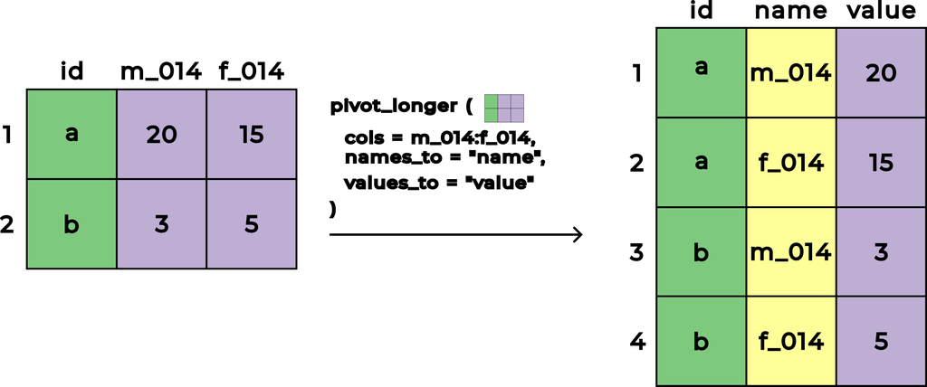

Figura 4: Representación conceptual de la función `pivot_longer()`

Las columnas `m_014` y `f_014` se colapsan en la columna `name`, sus conteos pasan a `value` y se duplica el identificador `id` para alargar la tabla de 2 a 4 filas.

## Formato ancho

- El **formato ancho** (*wider format*) es la **operación inversa** del formato largo: **aumenta columnas y reduce filas** (“ensanchar” los datos).
- Es fundamental cuando una observación se encuentra fragmentada en múltiples filas o para generar **matrices y tablas de presentación** donde las categorías se muestran como columnas.
- En `tidyr`, la función `pivot_wider()` implementa esta reestructuración mediante 2 parámetros clave:
  1. **`names_from`**: columna existente cuyos valores únicos se convertirán en los encabezados de las nuevas columnas.
  2. **`values_from`**: columna existente desde la cual se extraerán los valores de las celdas para poblar las nuevas columnas.

## Formato ancho

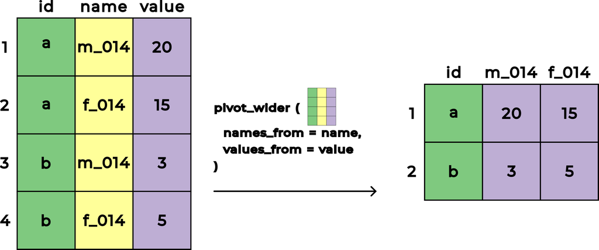

Figura 5: Representación conceptual de la función `pivot_wider()`

Los valores diferenciados de `name` (`m_014` y `f_014`) se convierten en nuevos encabezados de columna, rellenados con los registros de `value` y consolidando la tabla de 4 a 2 filas.

# Caso de estudio: estructurar datos en formato largo para generar pirámides poblacionales de Colombia

## Caso de estudio

- **Propósito**: aplicar la limpieza de nombres (`janitor`) y la transformación a formato largo (`pivot_longer()`) partiendo de proyecciones oficiales del DANE (2018–2070).
- **Insumo**: `serie-nacional-de-poblacion_area-sexo-edad_2018-2070_2025-07-18.xlsx`.
- **Objetivo**: generar el archivo `poblacion_col_2018_2070_largo.rds` para la posterior construcción de las pirámides poblacionales.
- **Flujo de trabajo**:
  1. **Importar**: `read_excel()` omitiendo metadatos con `skip = 8`.
  2. **Limpiar nombres**: `clean_names()` para estandarizar a *snake_case*.
  3. **Filtrar**: `filter()` para seleccionar únicamente el total nacional (`"Total"`).
  4. **Seleccionar**: `select()` para conservar `ano`, `total` y las 202 columnas demográficas.
  5. **Pivotear**: `pivot_longer()` para transformar de formato ancho a formato largo.
  6. **Exportar**: `write_rds()` para almacenar el conjunto de datos ordenado.

## Importar datos

```r
# Cargar paquetes ----
library(readxl)
library(janitor)
library(tidyverse)

# Importar datos ----
path <- "data/serie-nacional-de-poblacion_area-sexo-edad_2018-2070_2025-07-18.xlsx"

poblacion_col_2018_2070 <- read_excel(
  path = path,
  sheet = "PobNacionalxÁreaSexoEdad",
  skip = 8
) |>
  rename(
    territorio = `...1`,
    ano = `...2`,
    area_geografica = `...3`
  )

poblacion_col_2018_2070
```

```
# A tibble: 127 × 309
   territorio       ano area_geografica   Total Hombres Mujeres `Hombres 0 años`
   <chr>          <dbl> <chr>             <dbl>   <dbl>   <dbl>            <dbl>
 1 Total Nacional  2018 Cabecera         3.64e7  1.75e7  1.90e7           267725
 2 Total Nacional  2018 Centros Poblado… 1.18e7  6.16e6  5.68e6           111886
 3 Total Nacional  2018 Total            4.83e7  2.36e7  2.46e7           379611
 4 Total Nacional  2019 Cabecera         3.72e7  1.78e7  1.94e7           267420
 5 Total Nacional  2019 Centros Poblado… 1.20e7  6.27e6  5.78e6           112272
 6 Total Nacional  2019 Total            4.93e7  2.41e7  2.51e7           379692
 7 Total Nacional  2020 Cabecera         3.81e7  1.83e7  1.98e7           272089
 8 Total Nacional  2020 Centros Poblado… 1.23e7  6.38e6  5.88e6           113511
 9 Total Nacional  2020 Total            5.04e7  2.47e7  2.57e7           385600
10 Total Nacional  2021 Cabecera         3.87e7  1.86e7  2.01e7           269870
# ℹ 117 more rows
# ℹ 302 more variables: `Hombres 1 año` <dbl>, `Hombres 2 años` <dbl>,
#   `Hombres 3 años` <dbl>, `Hombres 4 años` <dbl>, `Hombres 5 años` <dbl>,
#   `Hombres 6 años` <dbl>, `Hombres 7 años` <dbl>, `Hombres 8 años` <dbl>,
#   `Hombres 9 años` <dbl>, `Hombres 10 años` <dbl>, `Hombres 11 años` <dbl>,
#   `Hombres 12 años` <dbl>, `Hombres 13 años` <dbl>, `Hombres 14 años` <dbl>,
#   `Hombres 15 años` <dbl>, `Hombres 16 años` <dbl>, …
```

## Limpieza de nombres con `clean_names()`

- La función `clean_names()` del paquete `janitor` transforma automáticamente los nombres a **snake_case**:
  - Pasa todo a minúsculas y sustituye espacios por guiones bajos (`_`).
  - Elimina acentos, tildes y caracteres especiales.
  - `` `Hombres 0 años` `` $\rightarrow$ `hombres_0_anos`
  - `` `Mujeres 100 años y más` `` $\rightarrow$ `mujeres_100_anos_y_mas`

## Limpieza de nombres con `clean_names()`

```r
# Limpiar nombres ----
poblacion_col_2018_2070_limpiar_nombres <- poblacion_col_2018_2070 |>
  clean_names()

poblacion_col_2018_2070_limpiar_nombres
```

```
# A tibble: 127 × 309
   territorio       ano area_geografica     total hombres mujeres hombres_0_anos
   <chr>          <dbl> <chr>               <dbl>   <dbl>   <dbl>          <dbl>
 1 Total Nacional  2018 Cabecera           3.64e7  1.75e7  1.90e7         267725
 2 Total Nacional  2018 Centros Poblados … 1.18e7  6.16e6  5.68e6         111886
 3 Total Nacional  2018 Total              4.83e7  2.36e7  2.46e7         379611
 4 Total Nacional  2019 Cabecera           3.72e7  1.78e7  1.94e7         267420
 5 Total Nacional  2019 Centros Poblados … 1.20e7  6.27e6  5.78e6         112272
 6 Total Nacional  2019 Total              4.93e7  2.41e7  2.51e7         379692
 7 Total Nacional  2020 Cabecera           3.81e7  1.83e7  1.98e7         272089
 8 Total Nacional  2020 Centros Poblados … 1.23e7  6.38e6  5.88e6         113511
 9 Total Nacional  2020 Total              5.04e7  2.47e7  2.57e7         385600
10 Total Nacional  2021 Cabecera           3.87e7  1.86e7  2.01e7         269870
# ℹ 117 more rows
# ℹ 302 more variables: hombres_1_ano <dbl>, hombres_2_anos <dbl>,
#   hombres_3_anos <dbl>, hombres_4_anos <dbl>, hombres_5_anos <dbl>,
#   hombres_6_anos <dbl>, hombres_7_anos <dbl>, hombres_8_anos <dbl>,
#   hombres_9_anos <dbl>, hombres_10_anos <dbl>, hombres_11_anos <dbl>,
#   hombres_12_anos <dbl>, hombres_13_anos <dbl>, hombres_14_anos <dbl>,
#   hombres_15_anos <dbl>, hombres_16_anos <dbl>, hombres_17_anos <dbl>, …
```

## Filtrar categoría de interés

- La columna `area_geografica` clasifica las proyecciones en 3 niveles:
  - `"Cabecera"`
  - `"Centros Poblados y Rural Disperso"`
  - `"Total"`
- Dado que el análisis se centra en la estructura demográfica nacional, filtramos únicamente `"Total"` con `filter()`.
- La tabla se reduce de 127 a **53 filas**, correspondientes a los 53 años comprendidos entre 2018 y 2070.

## Filtrar categoría de interés

```r
# Filtrar ----
poblacion_col_2018_2070_filtrar_total <- poblacion_col_2018_2070_limpiar_nombres |>
  filter(
    area_geografica == "Total"
  )

poblacion_col_2018_2070_filtrar_total
```

```
# A tibble: 53 × 309
   territorio       ano area_geografica    total  hombres mujeres hombres_0_anos
   <chr>          <dbl> <chr>              <dbl>    <dbl>   <dbl>          <dbl>
 1 Total Nacional  2018 Total           48258494 23614164  2.46e7         379611
 2 Total Nacional  2019 Total           49266526 24117643  2.51e7         379692
 3 Total Nacional  2020 Total           50390790 24679740  2.57e7         385600
 4 Total Nacional  2021 Total           51115637 25037263  2.61e7         382677
 5 Total Nacional  2022 Total           51643565 25294681  2.63e7         379263
 6 Total Nacional  2023 Total           52117067 25527864  2.66e7         375915
 7 Total Nacional  2024 Total           52613753 25777598  2.68e7         372539
 8 Total Nacional  2025 Total           53057212 26001235  2.71e7         367902
 9 Total Nacional  2026 Total           53399171 26174644  2.72e7         361692
10 Total Nacional  2027 Total           53712233 26333697  2.74e7         355501
# ℹ 43 more rows
# ℹ 302 more variables: hombres_1_ano <dbl>, hombres_2_anos <dbl>,
#   hombres_3_anos <dbl>, hombres_4_anos <dbl>, hombres_5_anos <dbl>,
#   hombres_6_anos <dbl>, hombres_7_anos <dbl>, hombres_8_anos <dbl>,
#   hombres_9_anos <dbl>, hombres_10_anos <dbl>, hombres_11_anos <dbl>,
#   hombres_12_anos <dbl>, hombres_13_anos <dbl>, hombres_14_anos <dbl>,
#   hombres_15_anos <dbl>, hombres_16_anos <dbl>, hombres_17_anos <dbl>, …
```

## Seleccionar variables de interés

```r
# Seleccionar ----
poblacion_col_2018_2070_seleccionar <- poblacion_col_2018_2070_filtrar_total |>
  select(
    ano,
    total,
    hombres_0_anos:mujeres_100_anos_y_mas
  )

poblacion_col_2018_2070_seleccionar
```

```
# A tibble: 53 × 204
     ano    total hombres_0_anos hombres_1_ano hombres_2_anos hombres_3_anos
   <dbl>    <dbl>          <dbl>         <dbl>          <dbl>          <dbl>
 1  2018 48258494         379611        384392         389812         395361
 2  2019 49266526         379692        386682         391193         396244
 3  2020 50390790         385600        388121         394740         398807
 4  2021 51115637         382677        389658         392098         398527
 5  2022 51643565         379263        384581         391602         393982
 6  2023 52117067         375915        380514         385906         392867
 7  2024 52613753         372539        377208         381864         387204
 8  2025 53057212         367902        373397         378139         382777
 9  2026 53399171         361692        367778         373403         378184
10  2027 53712233         355501        361449         367664         373324
# ℹ 43 more rows
# ℹ 198 more variables: hombres_4_anos <dbl>, hombres_5_anos <dbl>,
#   hombres_6_anos <dbl>, hombres_7_anos <dbl>, hombres_8_anos <dbl>,
#   hombres_9_anos <dbl>, hombres_10_anos <dbl>, hombres_11_anos <dbl>,
#   hombres_12_anos <dbl>, hombres_13_anos <dbl>, hombres_14_anos <dbl>,
#   hombres_15_anos <dbl>, hombres_16_anos <dbl>, hombres_17_anos <dbl>,
#   hombres_18_anos <dbl>, hombres_19_anos <dbl>, hombres_20_anos <dbl>, …
```

## Ordenar datos en formato largo

- Aunque la tabla seleccionada tiene todos los datos necesarios, no es ordenada porque los encabezados de edad y sexo representan valores y no variables.
- Con `pivot_longer()` transformamos las 202 columnas demográficas:
  - `cols = hombres_0_anos:mujeres_100_anos_y_mas`
  - `names_to = "genero_edad"`
  - `values_to = "poblacion"`
- Resultado: **10,706 filas** ($53 \text{ años} \times 202 \text{ categorías}$) y **4 columnas**.

## Ordenar datos en formato largo

```r
# Tidy ----
poblacion_col_2018_2070_largo <- poblacion_col_2018_2070_seleccionar |>
  pivot_longer(
    cols = hombres_0_anos:mujeres_100_anos_y_mas,
    names_to = "genero_edad",
    values_to = "poblacion"
  )

poblacion_col_2018_2070_largo
```

```
# A tibble: 10,706 × 4
     ano    total genero_edad    poblacion
   <dbl>    <dbl> <chr>              <dbl>
 1  2018 48258494 hombres_0_anos    379611
 2  2018 48258494 hombres_1_ano     384392
 3  2018 48258494 hombres_2_anos    389812
 4  2018 48258494 hombres_3_anos    395361
 5  2018 48258494 hombres_4_anos    400077
 6  2018 48258494 hombres_5_anos    405013
 7  2018 48258494 hombres_6_anos    410040
 8  2018 48258494 hombres_7_anos    415839
 9  2018 48258494 hombres_8_anos    421676
10  2018 48258494 hombres_9_anos    427467
# ℹ 10,696 more rows
```

## Exportar datos en formato largo

- Una vez estructurada la tabla en formato largo, la exportamos en formato binario `.rds` utilizando la función `write_rds()`.
- Este archivo será el insumo central en la próxima sesión para separar `genero_edad` en sus dos variables independientes (`genero` y `edad`) y generar el gráfico final.

```r
# Exportar datos ----
poblacion_col_2018_2070_largo |>
  write_rds(
    file = "data/poblacion_col_2018_2070_largo.rds"
  )
```

[output not shown]

Gracias

# Referencias

Wickham, Hadley. 2014. «Tidy Data». *Journal of Statistical Software* 59 (10). https://doi.org/10.18637/jss.v059.i10.

Wickham, Hadley. 2023. *R for Data Science*. 2.ª ed. O’Reilly Media, Incorporated. https://r4ds.hadley.nz/.